# Homework12

Carolyn Hanrahan

April 19, 2023

# Homework 11

- For homework 11 I plan on using the ToothGrowth built-in dataset in R to practice making some fun new ggplot graphics and base R plots. I begin by creating some basic plots and work on increasingly improving my data visualiazation through multiple iterations.

## Importing libraries and data:

```r
library(ggplot2)
library(ggthemes)
library(patchwork)
data("ToothGrowth")
head(ToothGrowth)
```

```
##    len supp dose
## 1  4.2   VC  0.5
## 2 11.5   VC  0.5
## 3  7.3   VC  0.5
## 4  5.8   VC  0.5
## 5  6.4   VC  0.5
## 6 10.0   VC  0.5
```

```r
d <- ToothGrowth
```

## Some Practice Graphs

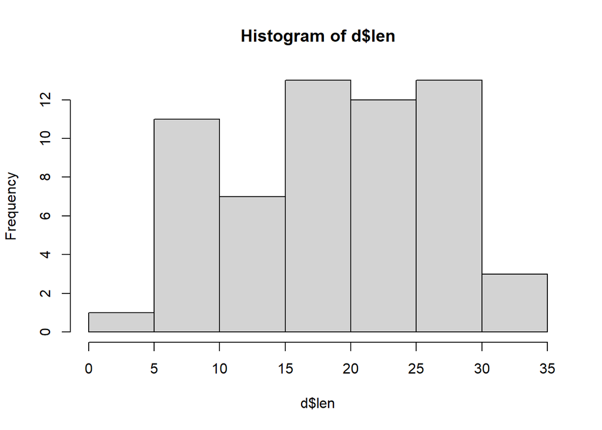

```r
hist(d$len)
```

```r
table(d$len)
```

```
##
##  4.2  5.2  5.8  6.4    7  7.3  8.2  9.4  9.7   10 11.2 11.5 13.6 14.5 15.2 15.5
##    1    1    1    1    1    1    1    1    2    2    2    1    1    3    2    1
## 16.5 17.3 17.6 18.5 18.8 19.7   20 21.2 21.5 22.4 22.5   23 23.3 23.6 24.5 24.8
##    3    2    1    1    1    1    1    1    2    1    1    1    2    2    1    1
## 25.2 25.5 25.8 26.4 26.7 27.3 29.4 29.5 30.9 32.5 33.9
##    1    2    1    4    1    2    1    1    1    1    1
```

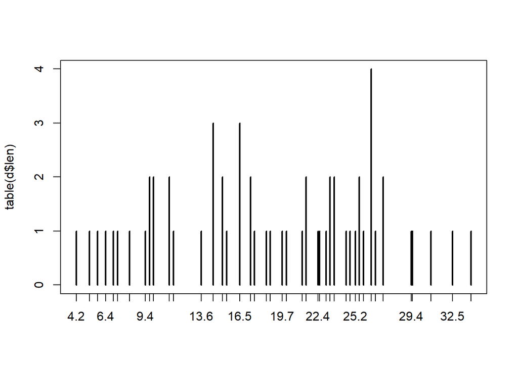

```r
plot(table(d$len))
```

## Basic Boxplot

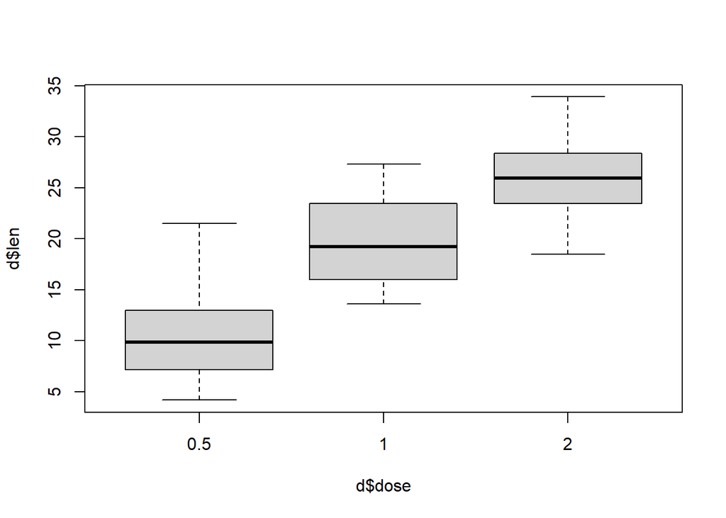

```r
e <- boxplot(d$len~d$dose)
```

## Utilizing ggplot :)

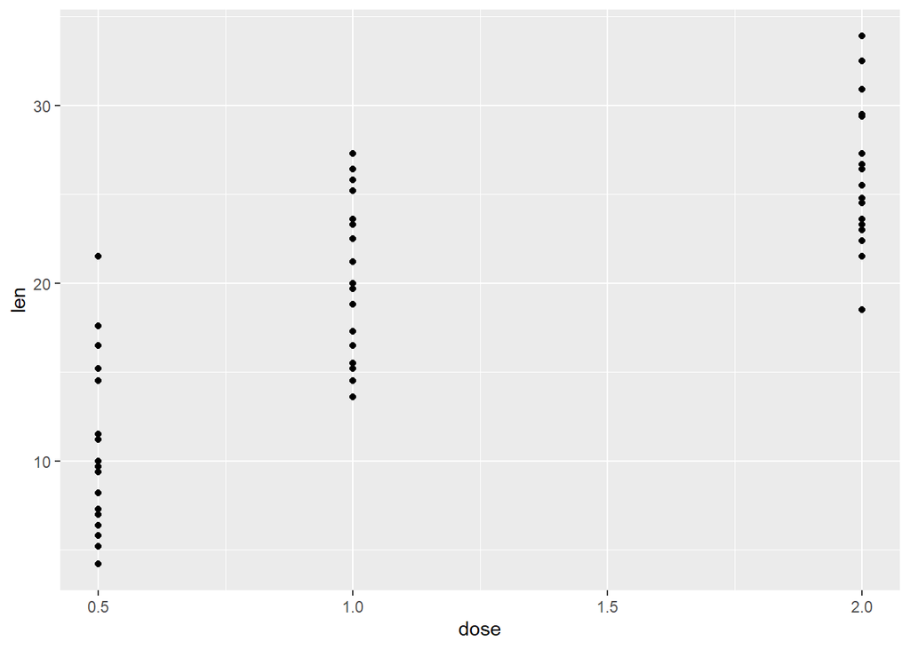

```r
p1 <- ggplot(data=d) +
               aes(x=dose,y=len)+
               geom_point()

print(p1)
```

- Adding more complexity…

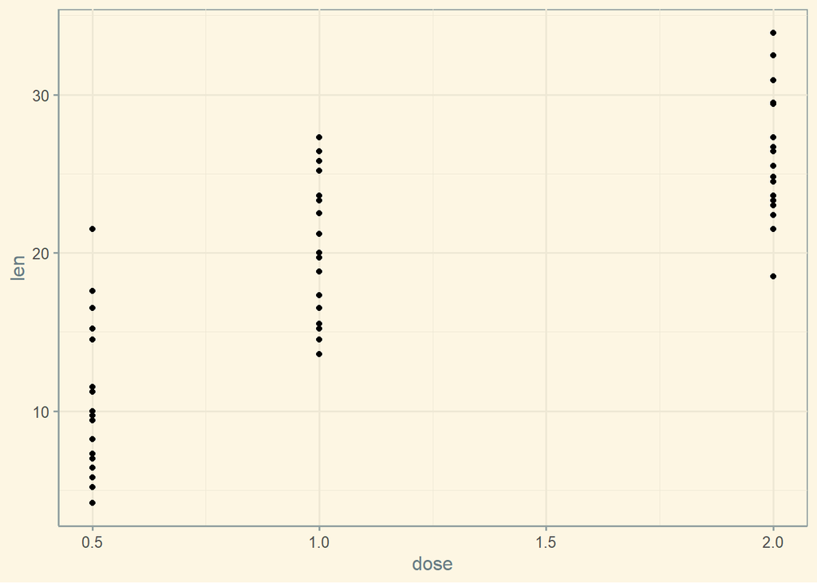

```r
p2 <- p1 + theme_solarized()
print(p2)
```

- and more…

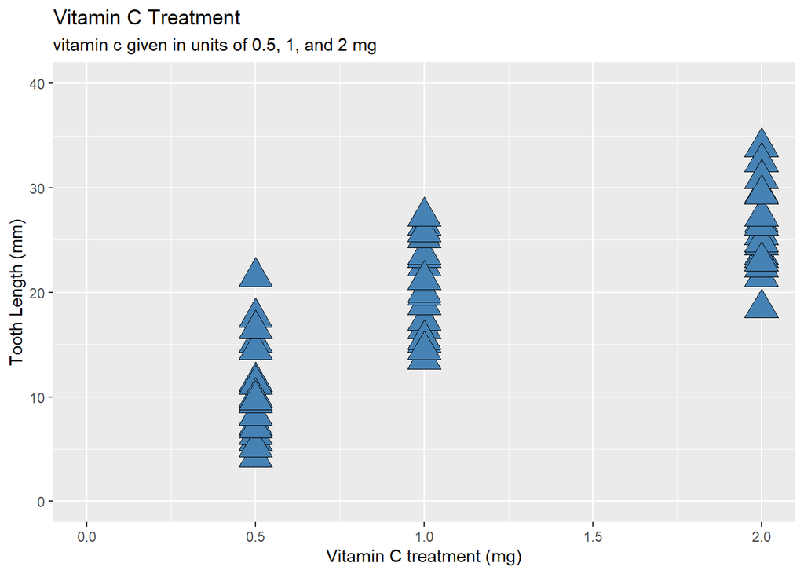

```r
p3 <- ggplot(data=d) +
  aes(x=dose,y=len) +
  geom_point(size=7,
             shape=24,
             color="black",
             fill="steelblue") +
  labs(title="Vitamin C Treatment",
       subtitle="vitamin c given in units of 0.5, 1, and 2 mg",
       x="Vitamin C treatment (mg)",
       y="Tooth Length (mm)") +
  xlim(0,2) + ylim(0,40)

print(p3)
```

- Testing out some totally new stuff from the R graph gallery: Ridge plot

```r
# library
library(ggridges)
```

```r
library(ggplot2)
library(viridis)
library(hrbrthemes)
x <- ggplot(data=d, aes(x = len, y = dose, fill = dose, group = dose)) +
  geom_density_ridges() +
  theme_ridges() +
  theme(legend.position = "left")
  labs(title='Tooth Length by Vitamin C Treatment Group')
```

```
## $title
## [1] "Tooth Length by Vitamin C Treatment Group"
##
## attr(,"class")
## [1] "labels"
```

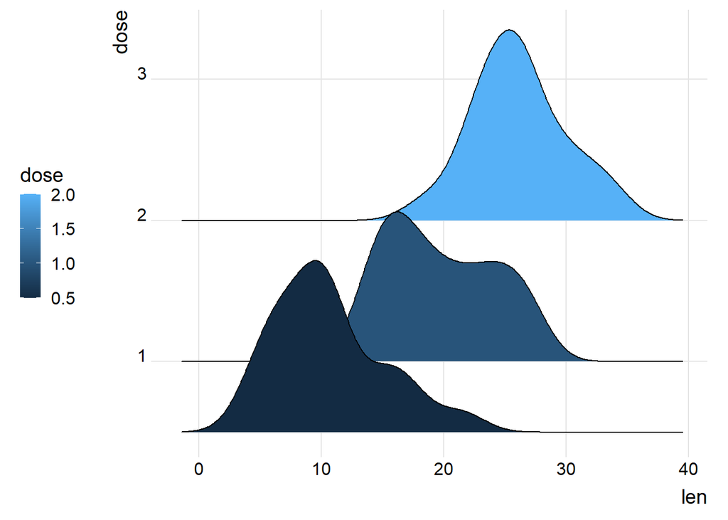

```r
print(x)
```

- Progressively adding more to the ridge plot…

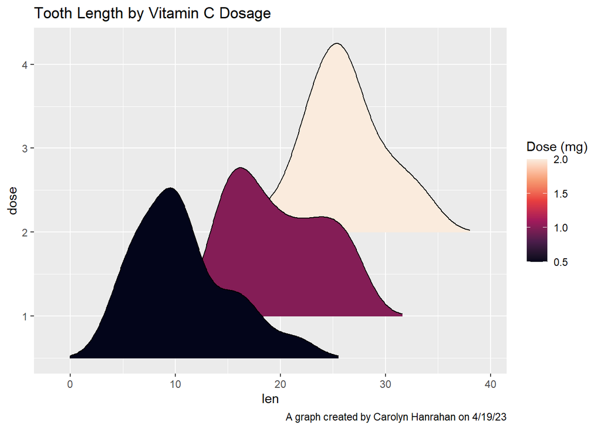

```r
y <- ggplot(d, aes(x = len, y = dose, fill = dose, group = dose)) +
  geom_density_ridges_gradient(scale = 3, rel_min_height = 0.01) +
  scale_fill_viridis_c(name = "Dose (mg)", option = "F") +
  labs(title = 'Tooth Length by Vitamin C Dosage')+
  labs(caption="A graph created by Carolyn Hanrahan on 4/19/23")

print(y)
```

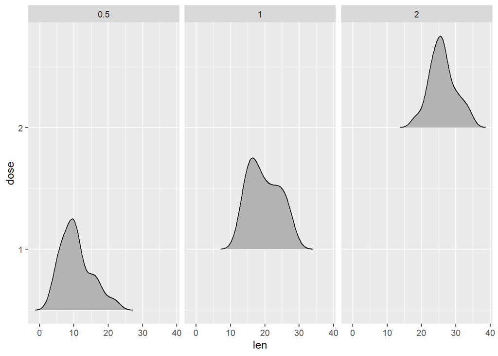

```r
ggsave("ToothLengthRidgeGraph.pdf")  #saving my graph to a pdf.
z<- ggplot(d, aes(x = len, y = dose)) +
  geom_density_ridges(scale = 1) + facet_wrap(~dose)


print(z)
```

- this graph puts each plot into its own little section.

## A New type of plot:

- 3D plot!This plot is not very well suited to this data because we only have 2 numeric categories. I am going to keep the code here, though:

```r
library(rgl)
```

```r
plot3d <- plot3d(
  x=d$dose, y=d$len, z=d$supp,
  col = "red","blue","yellow",
  type = 's',
  radius = .1,
  xlab="Dose", ylab="Tooth Length", zlab="Sup")

print(plot3d)
```

## Examining Supplement Type and Tooth Length (Orange juice vs.Ascorbic Acid)

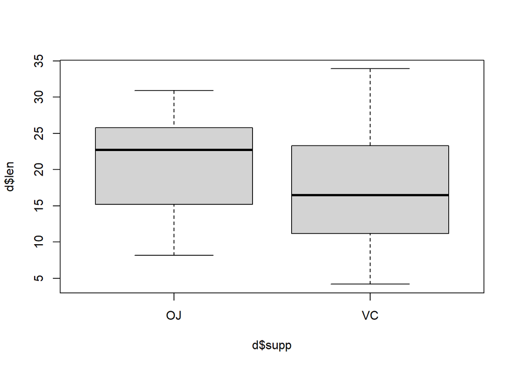

```r
boxplot(d$len~d$supp)
```

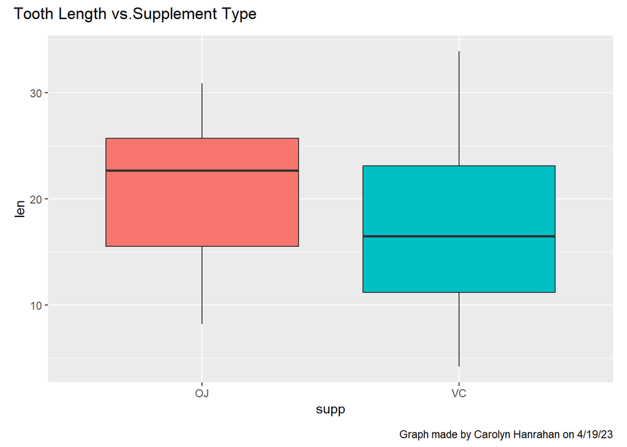

```r
s <- ggplot(data=d) +
  aes(x=supp,y=len,fill=supp) +
  geom_boxplot() +
  theme(legend.position="none")+
  plot_annotation(title="Tooth Length vs.Supplement Type",caption="Graph made by Carolyn Hanrahan on 4/19/23")

print(s)
```

- I feel as though this is a very nice and informative graph. You can clearly see that the supplement type of OJ result in greater tooth length.

## Saving my Graph

- I saved my last graph and named it “s”

```r
ggsave("SupplementType.pdf")
```

## Conclusion

- Overall I really enjoyed exploring the different graphing options in this lab!I feel like the last boxplot and some of the ridgeline graphs are effective examples of decent data visualizations.